# DevEcon_Project2

Hoda Noorbakhsh

2025-01-03

```r
knitr::opts_chunk$set(echo = TRUE, warning = FALSE, message = FALSE, cache = TRUE)
```

```r
library(readxl)
library(RODBC)
library(mdbr)
library(dplyr)
library(forcats)
library(ineq)
library(dplyr)
```

We first reda and clean HEIS data. We need data on durable and non-durable goods, household spending, income, and investment.

```r
#Read and clean data

db <- odbcDriverConnect("Driver={Microsoft Access Driver (*.mdb, *.accdb)};
    DBQ=F:/uni/master/3/Develop Economy/Project2/HB1402_14030707")
R1402Data <- sqlFetch(db, "R1402Data", rownames=TRUE)
U1402Data <- sqlFetch(db, "U1402Data", rownames=TRUE)

R1402P1 <- sqlFetch(db, "R1402P1", rownames=TRUE)
U1402P1 <- sqlFetch(db, "U1402P1", rownames=TRUE)

R1402P3S01 <- sqlFetch(db, "R1402P3S01", rownames=TRUE)
U1402P3S01 <- sqlFetch(db, "U1402P3S01", rownames=TRUE)

R1402P3S02 <- sqlFetch(db, "R1402P3S02", rownames=TRUE)
U1402P3S02 <- sqlFetch(db, "U1402P3S02", rownames=TRUE)

R1402P3S03 <- sqlFetch(db, "R1402P3S03", rownames=TRUE)
U1402P3S03 <- sqlFetch(db, "U1402P3S03", rownames=TRUE)

R1402P3S04 <- sqlFetch(db, "R1402P3S04", rownames=TRUE)
U1402P3S04 <- sqlFetch(db, "U1402P3S04", rownames=TRUE)

R1402P3S05 <- sqlFetch(db, "R1402P3S05", rownames=TRUE)
U1402P3S05 <- sqlFetch(db, "U1402P3S05", rownames=TRUE)

R1402P3S06 <- sqlFetch(db, "R1402P3S06", rownames=TRUE)
U1402P3S06 <- sqlFetch(db, "U1402P3S06", rownames=TRUE)

R1402P3S07 <- sqlFetch(db, "R1402P3S07", rownames=TRUE)
U1402P3S07 <- sqlFetch(db, "U1402P3S07", rownames=TRUE)

R1402P3S08 <- sqlFetch(db, "R1402P3S08", rownames=TRUE)
U1402P3S08 <- sqlFetch(db, "U1402P3S08", rownames=TRUE)

R1402P3S09 <- sqlFetch(db, "R1402P3S09", rownames=TRUE)
U1402P3S09 <- sqlFetch(db, "U1402P3S09", rownames=TRUE)

R1402P3S11 <- sqlFetch(db, "R1402P3S11", rownames=TRUE)
U1402P3S11 <- sqlFetch(db, "U1402P3S11", rownames=TRUE)

R1402P3S12 <- sqlFetch(db, "R1402P3S12", rownames=TRUE)
U1402P3S12 <- sqlFetch(db, "U1402P3S12", rownames=TRUE)

R1402P3S13 <- sqlFetch(db, "R1402P3S13", rownames=TRUE)
U1402P3S13 <- sqlFetch(db, "U1402P3S13", rownames=TRUE)

R1402P3S14 <- sqlFetch(db, "R1402P3S14", rownames=TRUE)
U1402P3S14 <- sqlFetch(db, "U1402P3S14", rownames=TRUE)

R1402P4S01 <- sqlFetch(db, "R1402P4S01", rownames=TRUE)
U1402P4S01 <- sqlFetch(db, "U1402P4S01", rownames=TRUE)

R1402P2 <- sqlFetch(db, "R1402P2", rownames=TRUE)
U1402P2 <- sqlFetch(db, "U1402P2", rownames=TRUE)
odbcClose(db)
```

```r
R1402P1_head <- R1402P1 %>%
  filter(member == "1")

RData1 <- merge(R1402Data, R1402P1_head, by = "Address")
RData <- RData1 %>%
  mutate(RU = 0)

U1402P1_head <- U1402P1 %>%
  filter(member == "1")

UData1 <- merge(U1402Data, U1402P1_head, by = "Address")
UData <- UData1 %>%
  mutate(RU = 1)

RUData <- rbind(UData, RData)

R1402P3S01 <- R1402P3S01 %>%
  mutate(RU = 1)
U1402P3S01 <- U1402P3S01 %>%
  mutate(RU = 0)

RUData_Food <- rbind(U1402P3S01, R1402P3S01)

R1402P2 <- R1402P2 %>%
  mutate(RU = 1)
U1402P2 <- U1402P2 %>%
  mutate(RU = 0)

RU1402P2 <- rbind(U1402P2, R1402P2)
```

```r
Province <- c(Markazi = "00", Ardabil = "24", Bushehr = "18", `Chaharmahal and Bakhtiari` = "14",
  `East Azerbaijan` = "03", Fars = "07", Gilan = "01", Golestan = "27",
  Hamadan = "13", Hormozgan = "22", Ilam = "16", Isfahan = "10",
  Kerman = "08", Kermanshah = "05", Khuzestan = "06", `Kohgiluyeh and Boyer-Ahmad` = "17",
  Kurdistan = "12", Lorestan = "15", Alborz = "30", Mazandaran = "02",
  `North Khorasan` = "28", Qazvin = "26", Qom = "25", `Razavi Khorasan` = "09",
  Semnan = "20", `Sistan and Baluchestan` = "11", `South Khorasan` = "29", Tehran = "23",
  `West Azerbaijan` = "04", Yazd = "21", Zanjan = "19")

RUData <- RUData %>%
  mutate(
    province_code = as.character(substr(Address, 2, 3)),
    province = recode(province_code, !!!Province),
    town = as.integer(substr(Address, 4, 5)),
         NEW_Weight = case_when(relation == "head" ~ 1,
                                (relation != "head" & age >= 18) ~ 0.8,
                                (relation != "head" & age < 18) ~ 0.5),
         adjusted_weight = Weight * NEW_Weight)

RUData_Food <- RUData_Food %>%
  left_join(select(RUData, Address, Weight), by = "Address") %>%
  left_join(select(RUData, Address, adjusted_weight), by = "Address") %>%
  left_join(select(RUData, Address, NEW_Weight), by = "Address") %>%
  left_join(select(RUData, Address, province), by = "Address")
```

Extract food items from data and label them.

```r
RUData_Food <- RUData_Food %>%
  mutate(label = case_when(
    code >= 11140 & code <= 11156 ~ "bread",
    code >= 11111 & code <= 11118 ~ "rice",
    code == 11164 ~ "spaghetti",
    code == 11731 | code == 11725 ~ "potato & pea",
    # Use | instead of &
    code >= 11411 & code <= 11414 ~ "milk",
    code >= 11424 & code <= 11426 ~ "yoghurt",
    (code == 11241) | (code >= 11211 & code <= 11224) ~ "Meat",
    code >= 11441 & code <= 11443 ~ "egg",
    code >= 11428 & code <= 11432 ~ "cheese",
    code >= 11611 & code <= 11643 ~ "fruit",
    (code >= 11711 & code <= 11716) | (code >= 11721 & code <= 11754) & code != 11731 ~ "vegetables",
    # Corrected logical grouping
    code == 11533 ~ "oil",
    code == 11812 | code == 11811 | (code >= 11821 & code <= 11823) ~ "sugar & Jam",
    # Corrected logical grouping
    code >= 11761 & code <= 11769 ~ "hobobat",
    ((code >= 11311 & code <= 11321) & code != 11319) | (code >= 11231 & code <= 11239) ~ "fish & chiken",
    # Corrected logical grouping
    TRUE ~ NA_character_))
```

Modify the “Kilogram” column and generate a data frame based on the above food bundle table.

```r
merged_data <- RUData_Food %>%
  mutate(across(c(price,value,gram,kilogram,Weight),  ~ as.numeric(as.character(.x)))) %>%
  mutate(gram = ifelse(is.na(gram), 0, gram/1000)) %>%
  mutate(kilogram = ifelse(is.na(kilogram), 0, kilogram)) %>%
  mutate(kilogram = kilogram + gram) %>%
  select(-gram)

prices <- merged_data %>%
  group_by(label, RU) %>%
  summarize(weighted_mean_price = sum(value * adjusted_weight, na.rm = TRUE) / sum(kilogram * adjusted_weight, na.rm = TRUE))
```

Here, we calculate the absolute poverty line based on the food bundle proposed by the Ministry of Health, providing **2,100 Kilo Calories per day** and the required protein contents.

```r
monthly_needs <- data.frame(
  label = c("bread", "rice", "spaghetti", "potato & pee", "hobobat", "milk", "yoghurt",
            "Meat", "fish & chiken", "egg", "cheese", "fruit", "vegetables", "oil", "sugar & jam"),
  needs_kg = c(8, 3, 0.7, 1.5, 0.6, 7, 3, 1.2, 1.5, 0.7, 0.45, 9, 4.5, 0.9, 1)
)
```

We use
$$\text{Weighted Mean Price} =
\frac{\sum_{i=1}^{n} (\text{weight}_i \times
\text{value}_i)}{\sum_{i=1}^{n} (\text{weight}_i \times
\text{kilogram}_i)}$$
to calculate the weighted mean.

```r
Total_cost_by_province <- merged_data %>%
  group_by(label, province) %>%
  dplyr::summarize(weighted_mean_price = weighted.mean(price, Weight, na.rm = TRUE)) %>%
  left_join(monthly_needs, by = "label") %>%
  mutate(total_product_cost = weighted_mean_price * needs_kg) %>%
  group_by(province) %>%
  summarise(total_bundle_price = sum(total_product_cost, na.rm = TRUE))
print(Total_cost_by_province)
```

```
## # A tibble: 31 x 2
##    province total_bundle_price
##    <chr>                 <dbl>
##  1 00                18822389.
##  2 01                19516394.
##  3 02                20270846.
##  4 03                17676324.
##  5 04                15318382.
##  6 05                17230349.
##  7 06                17081057.
##  8 07                16796759.
##  9 08                16966277.
## 10 09                15599746.
## # i 21 more rows
```

Provinces with highest absolute poverty line are **Tehran** and **Mazandaran**. Cost of food bundle for one person in a month is about **20,270,000 Rial**.

Provinces with lowest absolute poverty line are **Lorestan** with **14613179 Rial** and **West Azerbaijan** with **15318382 Rial**.

```r
Total_cost_RU <- merged_data %>%
  group_by(label, RU) %>%
  summarize(weighted_mean_price = sum(value * adjusted_weight, na.rm = TRUE) / sum(kilogram * adjusted_weight, na.rm = TRUE)) %>%
  left_join(monthly_needs, by = "label") %>%
  mutate(total_product_cost = weighted_mean_price * needs_kg) %>%
  group_by(RU) %>%
    summarize(total_bundle_price = sum(total_product_cost, na.rm = TRUE))
    print(Total_cost_RU)
```

```
## # A tibble: 2 x 2
##      RU total_bundle_price
##   <dbl>              <dbl>
## 1     0          16379500.
## 2     1          14487426.
```

```r
#Read Iranian Welfare Database

#IWD <- read.csv("F:/uni/master/3/Develop Economy/Project2/nemone_2_darsadi_1402.csv")
#save(IWD, file = "IWD.Rdata")
```

```r
load("IWD.Rdata")
```

In the absence of comprehensive and accurate data on household income, a proxy variable (ProxyIncome) was constructed to estimate income levels indirectly. This proxy combines two components:

[output not shown]

To construct ProxyIncome, the two components were combined with weightings of 90% for CardProxy and 10% for AssetsProxy. The higher weight for CardProxy reflects its stronger correlation with household cash flow and immediate financial activity, while AssetsProxy captures longer-term wealth that may influence income indirectly.

This proxy methodology is designed to provide a reasonable approximation of income distribution while accounting for limitations in the available data.

```r
IWD <- IWD %>%
  mutate(
    CardProxy = (CardBeCardPerMonth_1402 + PayaPerMonth_1402 + SatnaPerMonth_1402) / 1e6,
    AssetsProxy = (CarsPrice + Bourse_NetPortfoValue) / 1e6,
    ProxyIncome = (0.9 * CardProxy + 0.1 * AssetsProxy)
  ) %>%
  filter(ProxyIncome > 0 & ProxyIncome < quantile(ProxyIncome, 0.98, na.rm = TRUE))

summary(IWD$ProxyIncome)
```

```
##     Min.  1st Qu.   Median     Mean  3rd Qu.     Max.
##    0.001  256.998  466.526  822.596  911.546 7005.050
```

```r
gini_coeff <- Gini(IWD$ProxyIncome, na.rm = TRUE)
cat("Gini Coefficient (Using ProxyIncome):", gini_coeff, "\n")
```

```
## Gini Coefficient (Using ProxyIncome): 0.5296882
```

```r
total_income <- sum(IWD$ProxyIncome, na.rm = TRUE)
top_1_cutoff <- quantile(IWD$ProxyIncome, 0.98, na.rm = TRUE)

top_1_income <- IWD %>%
  filter(ProxyIncome > top_1_cutoff) %>%
  summarize(TotalTop1 = sum(ProxyIncome, na.rm = TRUE)) %>%
  pull(TotalTop1)

top_1_share <- top_1_income / total_income * 100
cat("Top 1% Share of Total Income:", round(top_1_share, 2), "%\n")
```

```
## Top 1% Share of Total Income: 13.47 %
```

Now use Lorenz Curve to illustrate the distribution of income or wealth within a population. It plots the cumulative percentage of income or wealth against the cumulative percentage of the population. In a perfectly equal distribution, the curve aligns with the diagonal line of perfect equality. The further the curve deviates from this diagonal, the greater the inequality in the distribution.

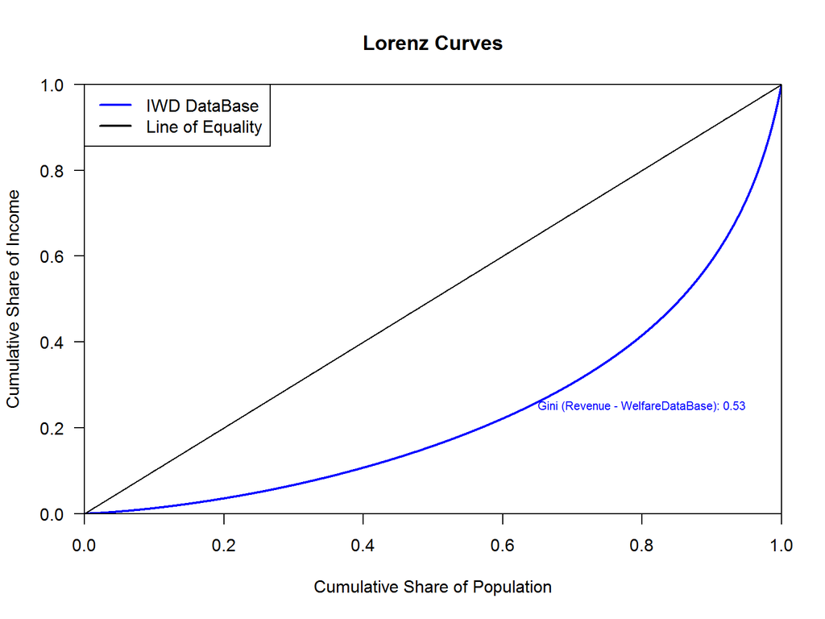

```r
# Compute Lorenz curves
lorenz_revenue <- Lc(IWD$ProxyIncome)
gini_revenue <- round(Gini(IWD$ProxyIncome), 2)
plot(lorenz_revenue,
     main = "Lorenz Curves",
     xlab = "Cumulative Share of Population",
     ylab = "Cumulative Share of Income",
     col = "blue",
     lwd = 2)
abline(0, 1, col = "black", lty = 2)

legend("topleft",
       legend = c("IWD DataBase", "Line of Equality"),
       col = c("blue", "black"),
       lty = c(1, 1, 1, 1),
       lwd = c(2, 2, 2, 2),
       bg = "white")

text(0.8, 0.25, paste("Gini (Revenue - WelfareDataBase):", gini_revenue), col = "blue", cex = 0.7)
```

```r
#library(labelled)
#library(leaflet)
#library(sf)

#MAP <- read_sf("F:/uni/master/3/Develop Economy/Project2/irn_admbnda_adm0_unhcr_20190514")
```